# 4-2-2022 Symbolic Python for Economic Analysis

- Name: Jikhan Jeong
- this is for a class so that please do not upload on the web.
- environment: **colab** to reduce package version control issues *Ref: https://docs.sympy.org/latest/tutorial/intro.html#what-is-symbolic-computation
- Ref: https://pythonforundergradengineers.com/sympy-expressions-and-equations.html

```python
print(f' my workding director in colab:')
!pwd
```

```
 my workding director in colab:
/content
```

```python
# Call packages
from sympy import *
import math
```

# Problems setting

- doupoly cournot competition with linear inverse demand function.
- symmetric case = marginal cost for firms 1 and 2 are the same.
- for better understadning, setting is the simplest setting

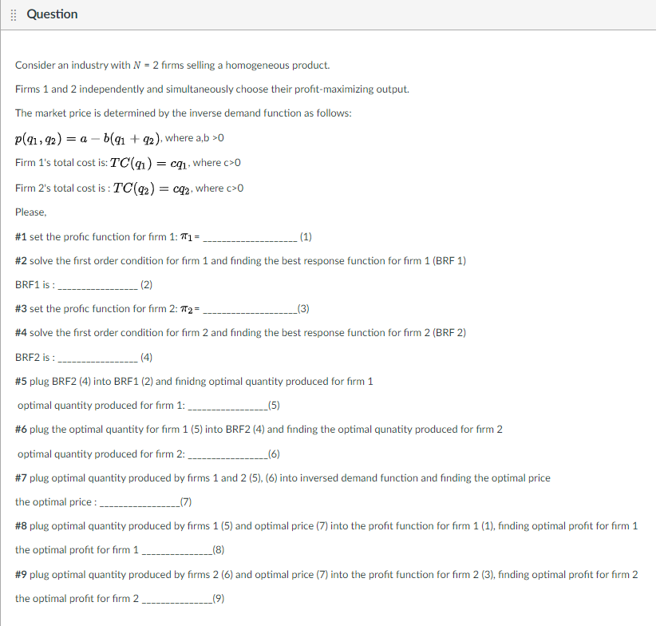

# Solve it with symbolic math using python

## * it will be useful for your future study when you solve more compelx setting

- we have 3 constant (a,b,c) and 2 parameters $q_1$ and $q_2$
- creating symbols for this five symbols

```python
a,b,c,q1,q2 = symbols('a b c q1 q2')
a,b,c,q1,q2
```

```
(a, b, c, q1, q2)
```

```python
print('Inverse demand curve:')
p = a-b*(q1+q2)
p
```

```
Inverse demand curve:
```

$\displaystyle a - b \left(q_{1} + q_{2}\right)$

```python
print('Total cost for firm 1:')
tc1 = c*q1
tc1
```

```
Total cost for firm 1:
```

$\displaystyle c q_{1}$

```python
print('Total cost for firm 2:')
tc2 = c*q2
tc2
```

```
Total cost for firm 2:
```

$\displaystyle c q_{2}$

```python
print('Total profit function for firm 1:')
profit1 = p*q1 - c*q1
profit1
```

```
Total profit function for firm 1:
```

$\displaystyle - c q_{1} + q_{1} \left(a - b \left(q_{1} + q_{2}\right)\right)$

```python
print('Expanded expression of Total profit function for firm 1:')
print('Total profit function for firm 1:')
profit1 = p*q1 - c*q1
expand(profit1)
```

```
Expanded expression of Total profit function for firm 1:
Total profit function for firm 1:
```

$\displaystyle a q_{1} - b q_{1}^{2} - b q_{1} q_{2} - c q_{1}$

```python
print('Total profit function for firm 2:')
profit2 = p*q2 - c*q2
profit2
```

```
Total profit function for firm 2:
```

$\displaystyle - c q_{2} + q_{2} \left(a - b \left(q_{1} + q_{2}\right)\right)$

```python
print('Expanded expression of Total profit function for firm 2:')
profit2 = p*q2 - c*q2
expand(profit2)
```

```
Expanded expression of Total profit function for firm 2:
```

$\displaystyle a q_{2} - b q_{1} q_{2} - b q_{2}^{2} - c q_{2}$

# First order condition

- differentiate each profit function with respect to the firm's quantity
- in symbolic math, using **diff** as follow:
- diff(euqation, variable)
- in our setting diff(profit function for firm a, firm a's quantity)
- answer for differenciation

# Firm 1 first order condition + best response function

```python
print('First order condition for firm 1:')
foc_q1 = diff(profit1, q1)
foc_q1 = Eq(foc_q1)
foc_q1
```

```
First order condition for firm 1:
```

$\displaystyle a - b q_{1} - b \left(q_{1} + q_{2}\right) - c = 0$

```python
print('Best response function for firm 1:')
BRF1 = solve(foc_q1, q1)
BRF1
```

```
Best response function for firm 1:
```

```
[(a - b*q2 - c)/(2*b)]
```

```python
BRF1 = (a - b*q2 - c)/(2*b)
expand(BRF1)
```

$\displaystyle \frac{a}{2 b} - \frac{q_{2}}{2} - \frac{c}{2 b}$

# Firm 2 first order condition + best response function

```python
print('First order condition for firm 2:')
foc_q2 = diff(profit2, q2)
foc_q2
```

```
First order condition for firm 2:
```

$\displaystyle a - b q_{2} - b \left(q_{1} + q_{2}\right) - c$

```python
print('Best response function for firm 1:')
BRF2 = solve(foc_q2, q2)
BRF2
```

```
Best response function for firm 1:
```

```
[(a - b*q1 - c)/(2*b)]
```

```python
BRF2 =  (a - b*q1 - c)/(2*b)
expand(BRF2)
```

$\displaystyle \frac{a}{2 b} - \frac{q_{1}}{2} - \frac{c}{2 b}$

# Optimal quantity for firm 1

- solve function give you a solution for
- equation = 0, the solution is based on the definend variable
- x+3y=0, if you want to solve it by x, then solve(x+3y, x), it will give you x=-3y

```python
# plug BRF2 into BRF1 then you can get the optimal quantity for firm 1
print('optimal qunaitity for firm 1:')
optimal_q1 = solve((a-b*BRF2-c)/(2*b)-q1,q1)
optimal_q1
```

```
optimal qunaitity for firm 1:
```

```
[(a - c)/(3*b)]
```

```python
print('optimal qunaitity for firm 1:')
optimal_q1 =(a - c)/(3*b)
optimal_q1
```

```
optimal qunaitity for firm 1:
```

$\displaystyle \frac{a - c}{3 b}$

# Optimal quantity for firm 2

```python
# plug optimal qunaity into BRF2 then you can get the optimal quantity for firm 2
print('optimal qunaitity for firm 2:')
optimal_q2 = solve((a-b*optimal_q1-c)/(2*b)-q2,q2)
optimal_q2
```

```
optimal qunaitity for firm 2:
```

```
[(a - c)/(3*b)]
```

```python
print('optimal qunaitity for firm 2:')
optimal_q2 = (a - c)/(3*b)
optimal_q2
```

```
optimal qunaitity for firm 2:
```

$\displaystyle \frac{a - c}{3 b}$

# Optimal price

- plug optimal quantity 1 and 2 into inverse demand function
- $ p^*=a-b(q^*_1+q^*_2)$

```python
print('optimal price for firms 1 and 2:')
optimal_price = a-b*(optimal_q1+optimal_q2)
optimal_price
```

```
optimal price for firms 1 and 2:
```

$\displaystyle \frac{a}{3} + \frac{2 c}{3}$

- **factor** function express equation more simple format : opposite effect with **expand** function

```python
print('optimal price for firms 1 and 2:')
factor(optimal_price)
```

```
optimal price for firms 1 and 2:
```

$\displaystyle \frac{a + 2 c}{3}$

# Maximum Profit for firm 1

- plug optimal price and quantity for firm 1 into profit fucntion for firm 1

```python
print('maximum profit for firm 1:')
max_profit1 = optimal_price*optimal_q1 -c*optimal_q1
max_profit1
```

```
maximum profit for firm 1:
```

$\displaystyle - \frac{c \left(a - c\right)}{3 b} + \frac{\left(\frac{a}{3} + \frac{2 c}{3}\right) \left(a - c\right)}{3 b}$

```python
print('maximum profit for firm 1:')
factor(max_profit1 )
```

```
maximum profit for firm 1:
```

$\displaystyle \frac{\left(a - c\right)^{2}}{9 b}$

# Maximum Profit for firm 2

- plug optimal price and quantity for firm 2 into profit fucntion for firm 2

```python
print('maximum profit for firm 2:')
max_profit2 = optimal_price*optimal_q2 -c*optimal_q2
max_profit2
```

```
maximum profit for firm 2:
```

$\displaystyle - \frac{c \left(a - c\right)}{3 b} + \frac{\left(\frac{a}{3} + \frac{2 c}{3}\right) \left(a - c\right)}{3 b}$

```python
print('maximum profit for firm 1:')
factor(max_profit2)
```

```
maximum profit for firm 1:
```

$\displaystyle \frac{\left(a - c\right)^{2}}{9 b}$

# Final Remark

- I usually start with ideas, then set up the target equations and list up the conditions.
- Then, I solve similar problems to come up required background
- After then, I solve it by my math with paper and pencil
- or using computational symbol math to check whether it has a solution or not.
- Roughly solving the model, I check whether it makes sense in economic intuition or not.
- Then, I check it with computations
- Yes, math is essential, but we have many good math friends and tools, so please keep your work for economics.
- Regard, JJ